# USA Election 2020 Polls & Ratings

The downfall of Trump…

Ed Wallitt

Last updated: 2020-07-12

# Introduction

This document aims to track the hoped downfall of the Donald Trump. Data is taken from the excellent [FiveThirtyEight](https://fivethirtyeight.com).

[Polls article](https://projects.fivethirtyeight.com/coronavirus-polls/)

We are going to use the BBC journalistic styling with Tufte!

```r
devtools::install_github('bbc/bbplot')
```

## COVID Approval Ratings

This data is based upon a selection of approval rating of how Trump has handled the coronavirus crisis

```r
data <- toplines %>%
  group_by(end_date) %>%
  summarize(
    approve_mean = mean(approve),
    disapprove_mean = mean(disapprove),
    cum_sample_size = sum(sample_size)
  ) %>%
  arrange(desc(end_date))
kable(head(data, n=10), col.names = c("Date", "Mean Approval", "Mean Disapproval", "Total Sample Size"))
```

| Date | Mean Approval | Mean Disapproval | Total Sample Size |
| --- | --- | --- | --- |
| 2020-06-16 | 43.43846 | 52.96154 | 13400.146 |
| 2020-06-15 | 42.22222 | 55.11111 | 5895.530 |
| 2020-06-14 | 39.69231 | 53.38462 | 11614.000 |
| 2020-06-13 | 44.90000 | 55.15000 | 3492.504 |
| 2020-06-10 | 43.66667 | 51.75000 | 22167.000 |
| 2020-06-09 | 44.08231 | 52.22846 | 10590.586 |
| 2020-06-08 | 41.50000 | 54.75000 | 3216.000 |
| 2020-06-07 | 40.23846 | 53.81538 | 11235.000 |
| 2020-06-06 | 41.32500 | 58.65000 | 3556.440 |
| 2020-06-05 | 43.40000 | 54.60000 | 5934.590 |

## Size of the polls

Let’s first examine the distribution of daily poll sample size

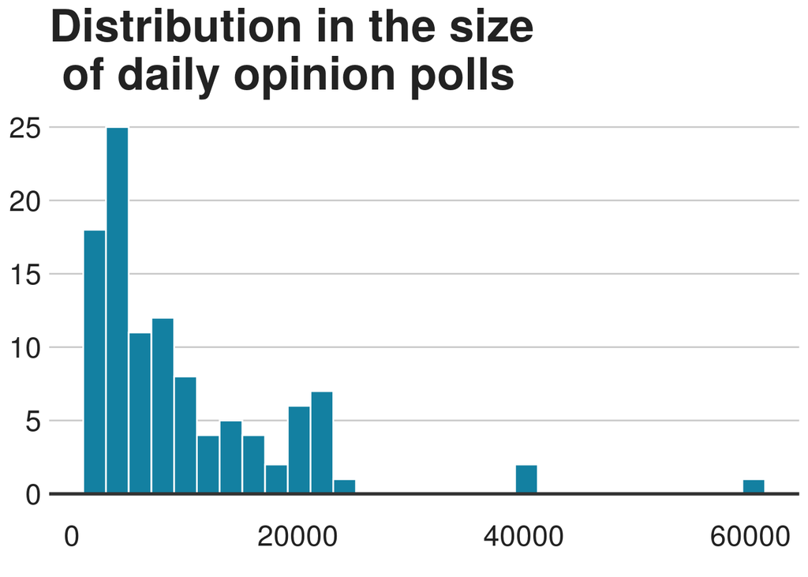

```r
ggplot(data, aes(cum_sample_size)) +
  geom_histogram(bins=30, colour = "white", fill = "#1380A1") +
  geom_hline(yintercept = 0, size = 1, colour="#333333") +
  bbc_style() +
  labs(
    title = 'Distribution in the size\n of daily opinion polls',
    x = "Sample Size",
    y = "Count"
  )
```

Most sample size are n < 20000, let’s look at those

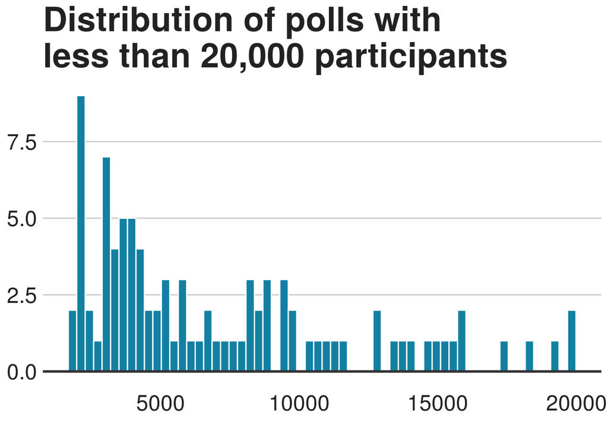

```r
data %>%
  filter(cum_sample_size < 20000) %>%
  ggplot(aes(cum_sample_size)) +
    geom_histogram(bins=60, colour = "white", fill = "#1380A1") +
    geom_hline(yintercept = 0, size=1, color="#333333") +
    bbc_style() +
    labs(
      title = 'Distribution of polls with \nless than 20,000 participants',
      x = "Sample Size",
      y = "Count"
    )
```

So while most polls have an **n number** less than 20,000, many of those are less than 5,000

## Changing approval

Let’s examine how approval (and disapproval) have changed over time. It would also be good to correlate the most significant changes with key political events.

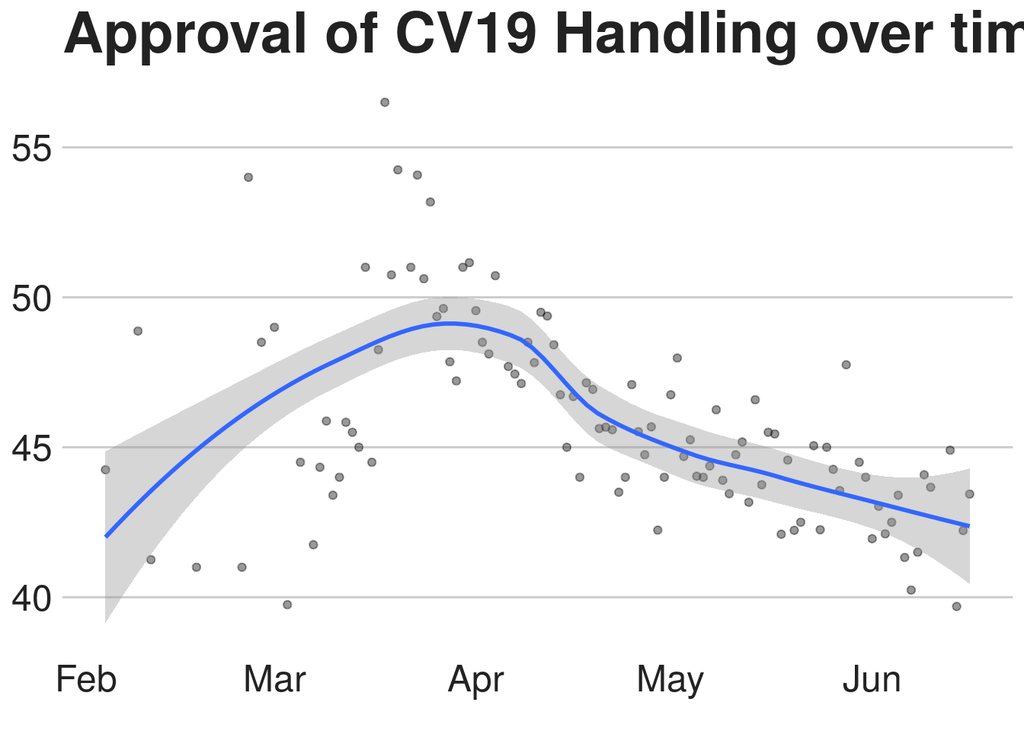

```r
data %>%
  ggplot(aes(end_date, approve_mean)) +
    geom_point(alpha=0.4) +
    geom_smooth(se=TRUE) +
    labs(
      title = "Approval of CV19 Handling over time (daily cumulative)",
      x = "Date",
      y = "Approval"
    ) +
    bbc_style()
```

This data is just using the summarised polls for each day, what happens if we use the entire **topline** dataset

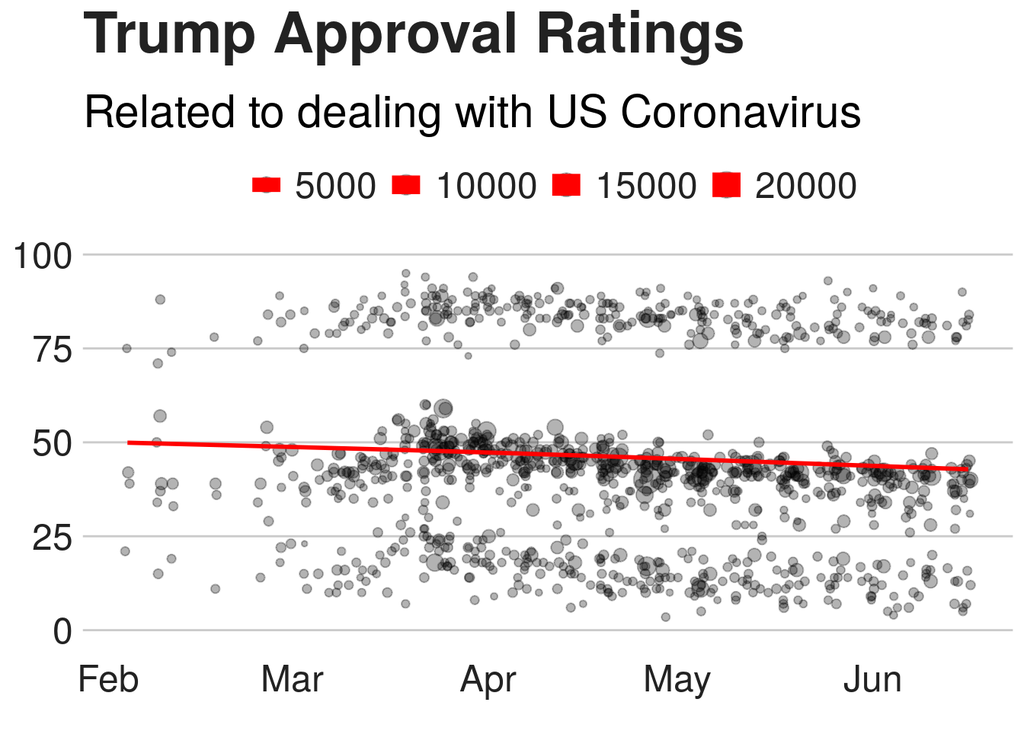

```r
toplines %>%
  ggplot(aes(end_date, approve, size=sample_size)) +
    geom_point(alpha=0.3, position = 'jitter') +
    geom_smooth(se=FALSE, color='red') +
    labs(
      title = "Trump Approval Ratings",
      subtitle = "Related to dealing with US Coronavirus",
      caption = "Source: FiveThirtyEight",
      x = "Date",
      y = "Approval %"
    ) +
    ylim(c(0, 100)) +
    bbc_style()
```

Looking at the clustering of points we can see that the darker cluster are more centralised - indicating that the majority of opinion is probably here

It’s very clear that there are three separate clusters on approval. These are probably down to party political allegiance. Let’s look at another version but split by party allegiance.

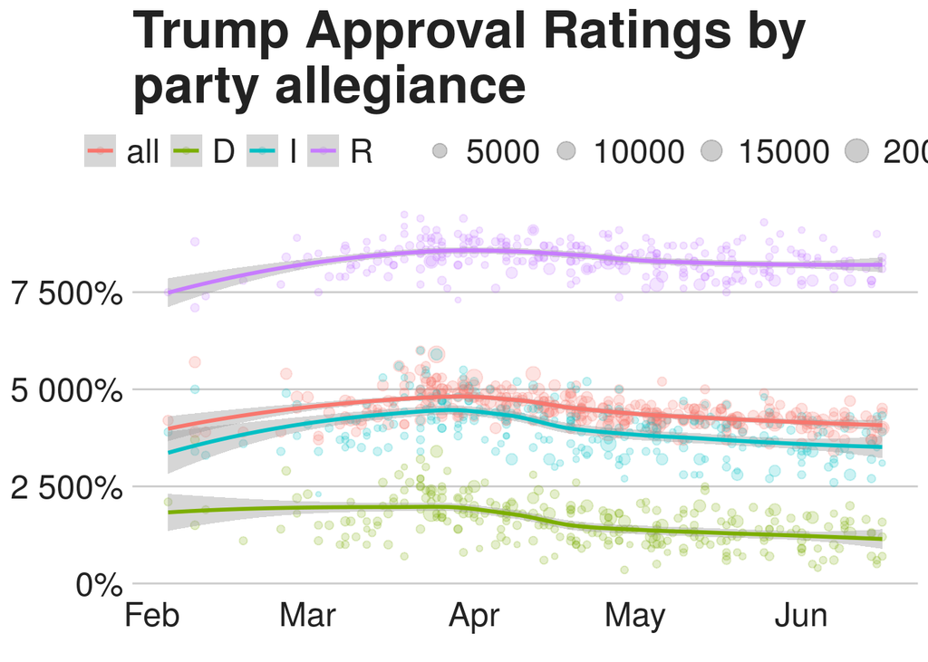

```r
allegiance <- toplines %>%
  ggplot(aes(end_date, approve, color=party)) +
    geom_point(aes(size=sample_size), alpha=0.2) +
    geom_smooth() +
    labs(
      title = "Trump Approval Ratings by \nparty allegiance",
      caption = "Source: FiveThirtyEight",
      x = "Date",
      y = "Approval"
    ) +
    theme(legend.position = "bottom",
        legend.justification = "left") +
    guides(fill = guide_legend(reverse = TRUE)) +
    scale_y_continuous(labels = scales::percent) +
   bbc_style()
allegiance
```